# New Jersey Transit Train Delay Prediction

Yifei Sun

2022-12-16

# Introduction

### What’s all this for?

The New York Metropolitan area has a problem.

New Jersey Transit (NJT), the third largest public transportation system in the United States, operates a fleet of ~1,200 active trains every day, accounting for early 300 million rides annually across more than 5,000 square miles serviced area. Featuring rail stations across three states, commuters from across the Northeast rely on the transit network to get to work, school, and other daily activities safely, quickly, and reliably.

Despite the important role the NJT plays in the lives of its commuters, there is currently no publicly-available system to accurately predict potential train delays in any of the station lines. This presents a big problem for commuters, as delayed trains drastically affect one’s ability to perform daily tasks and arrive to scheduled meetings on time. Having an accessing which trains are likely to be late puts the power back in the hands of the commuters, who are often left behind in the event of train malfunction. This report aims to suggest one solution to this issue.

# Data and Methodology

Data is pulled from the following link: [https://www.kaggle.com/datasets/pranavbadami/nj-transit-amtrak-nec-performance?select=2018_11.csv] The dataset reports on train delay minutes for the entirety of the NJ Transit rail system, as well as selected Amtrak lines, from March 2018 to May 2020.

# Analysis

### Read Data

First, we read in the data found on Kaggle, as well as the shapefile for the area of study. Once imported, we group aspects of the scheduled time of arrival for each train by its expected arrival hour, day, and week. This will help in later analysis.

```r
dat <- read.csv(file.path("2019_01.csv"))
station <-read.csv(file.path("stops.csv"))
dat<-merge(dat, station, by.x="from", by.y="stop_name")
dat <- dat%>%
  rename(
         from_lat = stop_lat,
         from_lng = stop_lon,
         from_zone_id=zone_id)
dat<-merge(dat, station, by.x="to", by.y="stop_name")
dat <- dat%>%
  rename(
         to_lat = stop_lat,
         to_lng = stop_lon,
         to_zone_id=zone_id)%>%
  dplyr::select(-stop_id.x,-stop_code.x,-stop_id.y,-stop_code.y)


# set 60 minute intervals
dat <- dat %>%
  mutate(interval60 = floor_date(ymd_hm(scheduled_time), unit = "hour"),
         week = week(interval60),
         dotw = wday(interval60, label=TRUE))

# load census geography
NJCensus <-
  get_acs(geography = "tract",
          variables = c("B01003_001", "B19013_001",
                        "B02001_002", "B08013_001",
                        "B08012_001", "B08301_001",
                        "B08301_010", "B01002_001"),
          year = 2018,
          state = "NJ",
          geometry = TRUE,

          output = "wide")
NJTracts <-
  NJCensus %>%
  as.data.frame() %>%
  distinct(GEOID, .keep_all = TRUE) %>%
  select(GEOID, geometry) %>%
  st_sf
```

```r
dat_census <- st_join(dat %>%
          filter(is.na(from_lng) == FALSE &
                   is.na(from_lat) == FALSE &
                   is.na(to_lat) == FALSE &
                   is.na(to_lng) == FALSE) %>%
          st_as_sf(., coords = c("from_lng", "from_lat"), crs = 4326),
        NJTracts %>%
          st_transform(crs=4326),
        join=st_intersects,
              left = TRUE) %>%
  rename(From.Tract = GEOID) %>%
  mutate(from_lng = unlist(map(geometry, 1)),
         from_lat = unlist(map(geometry, 2)))%>%
  as.data.frame() %>%
  select(-geometry)%>%
  st_as_sf(., coords = c("to_lng", "to_lat"), crs = 4326) %>%
  st_join(., NJTracts %>%
            st_transform(crs=4326),
          join=st_intersects,
          left = TRUE) %>%
  rename(To.Tract = GEOID)  %>%
  mutate(to_lng = unlist(map(geometry, 1)),
         to_lat = unlist(map(geometry, 2)))%>%
  as.data.frame() %>%
  select(-geometry)
```

### Evaluating Weather Patterns

The following graphs highlight an example of the weather conditions later explored in the model: Precipitation, Wind Speed, Temperature, and Visibility.

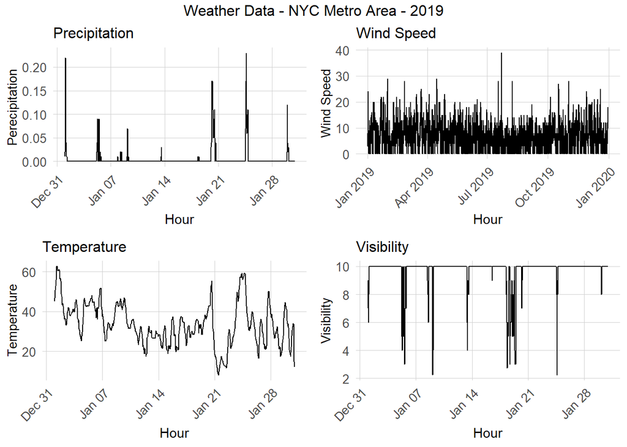

```r
weather.Data <-
  riem_measures(station = "WRI", date_start = "2019-01-01", date_end = "2019-12-31")
weather.Panel  <-
  weather.Data %>%
  dplyr::select(valid, tmpf, p01i, sknt, vsby)%>%
  replace(is.na(.), 0) %>%
    mutate(interval60 = ymd_h(substr(valid,1,13))) %>%
    mutate(week = week(interval60),
           dotw = wday(interval60, label=TRUE)) %>%
    group_by(interval60) %>%
    summarize(Temperature = max(tmpf),
              Precipitation = sum(p01i),
              Wind_Speed = max(sknt),
              Visibility = max(vsby)) %>%
    mutate(Temperature = ifelse(Temperature == 0, 42, Temperature))



#sample weather data for graph

weather.Data2 <-
  riem_measures(station = "WRI", date_start = "2019-01-01", date_end = "2019-01-31")
weather.Panel2  <-
  weather.Data2 %>%
  dplyr::select(valid, tmpf, p01i, sknt, vsby)%>%
  replace(is.na(.), 0) %>%
    mutate(interval60 = ymd_h(substr(valid,1,13))) %>%
    mutate(week = week(interval60),
           dotw = wday(interval60, label=TRUE)) %>%
    group_by(interval60) %>%
    summarize(Temperature = max(tmpf),
              Precipitation = sum(p01i),
              Wind_Speed = max(sknt),
              Visibility = max(vsby)) %>%
    mutate(Temperature = ifelse(Temperature == 0, 42, Temperature))


# plot
grid.arrange( ncol=2,
  ggplot(weather.Panel2, aes(interval60,Precipitation)) + geom_line() +
    labs(title="Precipitation", x="Hour", y="Perecipitation") + plotTheme,
  ggplot(weather.Panel, aes(interval60,Wind_Speed)) + geom_line() +
    labs(title="Wind Speed", x="Hour", y="Wind Speed") + plotTheme,
  ggplot(weather.Panel2, aes(interval60,Temperature)) + geom_line() +
    labs(title="Temperature", x="Hour", y="Temperature") + plotTheme,
  ggplot(weather.Panel2, aes(interval60,Visibility)) + geom_line() +
    labs(title="Visibility", x="Hour", y="Visibility") + plotTheme,
  top="Weather Data - NYC Metro Area - 2019")
```

### Further Data Cleaning + Lagged Variables

Further data cleaning is needed in order to render the information useful to building out the model. First, we join the weather data to the appropriate stations as seen across the three states.

Next, holidays and special events are added to the analysis. This is particularly important, as different holidays throughout the year are common sources of rush hour traffic for both car and public transit commuting populations.

Lastly, lagged variables are created from previous delayed minutes along each train route. Analyzing temporally-lagged variables are essential to this study, as understanding the previous delays of a given train will heavily inform the likelihood of the train arriving late to its next station.

```r
trip_panel<-merge(dat_census, weather.Panel)%>%
  rename(GEOID=From.Tract)%>%
left_join(NJTracts, trip_panel1, by='GEOID')
trip_panel$format_date<-format(trip_panel$interval60, "%Y-%m-%d")

trip_panel$holiday <- ifelse(yday(trip_panel$scheduled_time)%in% c(
  #New Years
  "365", "1", "2",
  # St. Patrick's Day
  "76",
  # 4th of July
  "185",
  #Halloween
  "304",
  #Christmas/Eve
  "358","359"
  ), 1,0)


#time lag variables
trip_panel <-
  trip_panel %>%
  arrange( interval60) %>%
  mutate(lagHour = dplyr::lag(delay_minutes,1),
         lag2Hours = dplyr::lag(delay_minutes,2),
         lag3Hours = dplyr::lag(delay_minutes,3),
         lag4Hours = dplyr::lag(delay_minutes,4),
         lag12Hours = dplyr::lag(delay_minutes,12),
         lag1day = dplyr::lead(delay_minutes,24),
         leadHour = dplyr::lead(delay_minutes,1),
         lead2Hours = dplyr::lead(delay_minutes,2),
         lead3Hours = dplyr::lead(delay_minutes,3),
         lead4Hours = dplyr::lead(delay_minutes,4),
         lead12Hours = dplyr::lead(delay_minutes,12),
         lead1day = dplyr::lead(delay_minutes,24)
        )%>%
  mutate(holidayLag = case_when(dplyr::lag(holiday, 1) == 1 ~ "PlusOneDay",
                                 dplyr::lag(holiday, 2) == 1 ~ "PlustTwoDays",
                                 dplyr::lag(holiday, 3) == 1 ~ "PlustThreeDays",
                                 dplyr::lead(holiday, 1) == 1 ~ "MinusOneDay",
                                 dplyr::lead(holiday, 2) == 1 ~ "MinusTwoDays",
                                 dplyr::lead(holiday, 3) == 1 ~ "MinusThreeDays"))%>%

   mutate(holidayLag = ifelse(is.na(holidayLag),0,holidayLag))
```

### CHECK

```r
as.data.frame(trip_panel) %>%
    group_by(interval60) %>%
    summarise_at(vars(starts_with("lag"), "delay_minutes"), mean, na.rm = TRUE) %>%
    gather(Variable, Value, -interval60, -delay_minutes) %>%
    mutate(Variable = factor(Variable, levels=c("lagHour","lag2Hours","lag3Hours","lag4Hours",
                                                "lag12Hours","lag1day")))%>%
    group_by(Variable) %>%
    summarize(correlation = round(cor(Value, delay_minutes),2))
```

```
## # A tibble: 6 × 2
##   Variable   correlation
##   <fct>            <dbl>
## 1 lagHour           0.95
## 2 lag2Hours         0.92
## 3 lag3Hours         0.78
## 4 lag4Hours        NA
## 5 lag12Hours       NA
## 6 lag1day          NA
```

```r
as.data.frame(trip_panel) %>%
    group_by(interval60) %>%
    summarise_at(vars(starts_with("lead"), "delay_minutes"), mean, na.rm = TRUE) %>%
    gather(Variable, Value, -interval60, -delay_minutes) %>%
    mutate(Variable = factor(Variable, levels=c("leadHour","lead2Hours","lead3Hours","lead4Hours",
                                                "lead12Hours","lead1day")))%>%
    group_by(Variable) %>%
    summarize(correlation = round(cor(Value, delay_minutes),2))
```

```
## # A tibble: 6 × 2
##   Variable    correlation
##   <fct>             <dbl>
## 1 leadHour             NA
## 2 lead2Hours           NA
## 3 lead3Hours           NA
## 4 lead4Hours           NA
## 5 lead12Hours          NA
## 6 lead1day             NA
```

### CHECK

split

```r
trip.Train <- filter(trip_panel, week < 5)
trip.Test <- filter(trip_panel, week >= 5)
```

### CHECK

delay time by week

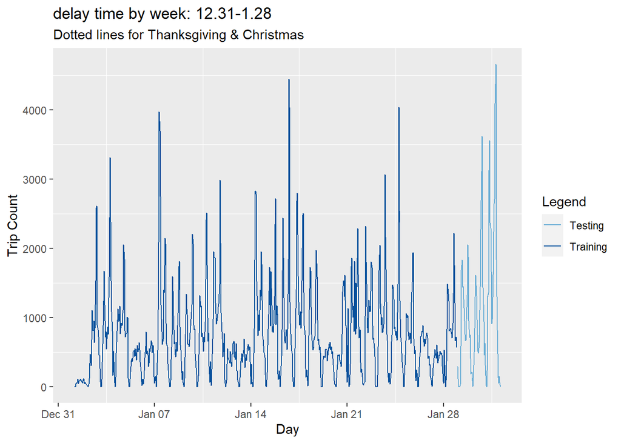

```r
mondays <-
  mutate(trip_panel,
         monday = ifelse(dotw == "Monday一" & hour(interval60) == 1,
                         interval60, 0)) %>%
  filter(monday != 0)

tg   <- as.POSIXct("2018-11-22 01:00:00 UTC")
xmas <- as.POSIXct("2018-12-24 01:00:00 UTC")

st_drop_geometry(rbind(
  mutate(trip.Train, Legend = "Training"),
  mutate(trip.Test, Legend = "Testing"))) %>%
    group_by(Legend, interval60) %>%
      summarize(delay_minutes = sum(delay_minutes)) %>%
      ungroup() %>%
      ggplot(aes(interval60, delay_minutes, colour = Legend)) + geom_line() +
        scale_colour_manual(values = palette2) +
        geom_vline(data = mondays, aes(xintercept = monday)) +
        labs(title="delay time by week: 12.31-1.28",
             subtitle="Dotted lines for Thanksgiving & Christmas",
             x="Day", y="Trip Count") +
         theme(panel.grid.major = element_blank())
```

### CHECK

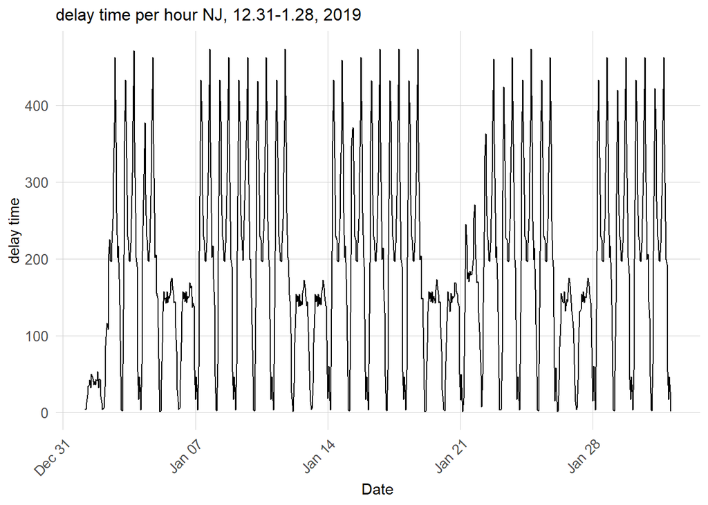

```r
ggplot(trip_panel %>%
         group_by(interval60) %>%
         tally())+
  geom_line(aes(x = interval60, y = n))+
  labs(title="delay time per hour NJ, 12.31-1.28, 2019",
       x="Date",
       y="delay time")+
  plotTheme
```

### Building the Model

Here, we explore two linear models used to explain each of the predictive variables for the analysis, one using the basic weather variables, while the other utilizes the lagged variables created earlier.

It may be predicted that the second model will provide a better fit in the expected delay minutes, as the lagged time variables begin to paint a more clear picture of the recent past performance for each of the trains.

```r
reg1 <- lm(delay_minutes~Temperature+Precipitation+Wind_Speed+Visibility, data=trip.Train )

reg2 <-
  lm(delay_minutes ~  line+holiday +  hour(interval60) + Temperature + Precipitation +Wind_Speed+Visibility+lagHour + lag2Hours +lag3Hours + lag12Hours + lag1day+holidayLag+leadHour+lead2Hours+lead3Hours+lead4Hours+lead12Hours+lead1day+from,
     data=trip.Train)


summary(reg1)
```

```
##
## Call:
## lm(formula = delay_minutes ~ Temperature + Precipitation + Wind_Speed +
##     Visibility, data = trip.Train)
##
## Residuals:
##     Min      1Q  Median      3Q     Max
##  -5.956  -3.095  -1.467   1.042 147.234
##
## Coefficients:
##                Estimate Std. Error t value Pr(>|t|)
## (Intercept)    3.845078   0.152376  25.234  < 2e-16 ***
## Temperature   -0.033566   0.001778 -18.878  < 2e-16 ***
## Precipitation  3.295464   0.914021   3.605 0.000312 ***
## Wind_Speed     0.078530   0.003342  23.499  < 2e-16 ***
## Visibility     0.080940   0.014592   5.547 2.91e-08 ***
## ---
## Signif. codes:  0 '***' 0.001 '**' 0.01 '*' 0.05 '.' 0.1 ' ' 1
##
## Residual standard error: 5.707 on 120667 degrees of freedom
## Multiple R-squared:  0.00715,    Adjusted R-squared:  0.007117
## F-statistic: 217.3 on 4 and 120667 DF,  p-value: < 2.2e-16
```

```r
summary(reg2)
```

```
##
## Call:
## lm(formula = delay_minutes ~ line + holiday + hour(interval60) +
##     Temperature + Precipitation + Wind_Speed + Visibility + lagHour +
##     lag2Hours + lag3Hours + lag12Hours + lag1day + holidayLag +
##     leadHour + lead2Hours + lead3Hours + lead4Hours + lead12Hours +
##     lead1day + from, data = trip.Train)
##
## Residuals:
##     Min      1Q  Median      3Q     Max
## -25.305  -2.713  -1.082   1.045 147.562
##
## Coefficients: (1 not defined because of singularities)
##                               Estimate Std. Error t value Pr(>|t|)
## (Intercept)                   1.444963   0.374577   3.858 0.000115 ***
## lineGladstone Branch          0.577491   0.259329   2.227 0.025958 *
## lineMain Line                -0.012890   0.110195  -0.117 0.906884
## lineMontclair-Boonton         1.729817   0.268166   6.451 1.12e-10 ***
## lineMorristown Line           1.022295   0.255984   3.994 6.51e-05 ***
## lineNo Jersey Coast           1.911595   0.306428   6.238 4.44e-10 ***
## lineNortheast Corrdr          2.151158   0.304986   7.053 1.76e-12 ***
## linePascack Valley            0.155730   0.312034   0.499 0.617724
## lineRaritan Valley            0.399539   0.420567   0.950 0.342114
## holiday                       1.212568   5.480262   0.221 0.824890
## hour(interval60)              0.020272   0.002907   6.975 3.08e-12 ***
## Temperature                  -0.020560   0.001822 -11.283  < 2e-16 ***
## Precipitation                 2.256291   0.883398   2.554 0.010647 *
## Wind_Speed                    0.041433   0.003286  12.609  < 2e-16 ***
## Visibility                    0.038236   0.014067   2.718 0.006568 **
## lagHour                       0.039896   0.002821  14.143  < 2e-16 ***
## lag2Hours                     0.050863   0.002821  18.028  < 2e-16 ***
## lag3Hours                     0.051759   0.002820  18.352  < 2e-16 ***
## lag12Hours                    0.041626   0.002818  14.769  < 2e-16 ***
## lag1day                       0.044280   0.002812  15.746  < 2e-16 ***
## holidayLagPlusOneDay         -1.200146   5.479732  -0.219 0.826638
## holidayLagPlustThreeDays      0.921512   5.481583   0.168 0.866497
## holidayLagPlustTwoDays        0.401787   5.479275   0.073 0.941545
## leadHour                      0.037556   0.002823  13.303  < 2e-16 ***
## lead2Hours                    0.051643   0.002822  18.303  < 2e-16 ***
## lead3Hours                    0.052209   0.002820  18.512  < 2e-16 ***
```

[output cut: 129 more lines]

```
## fromWATCHUNG AVENUE          -0.450814   0.322628  -1.397 0.162320
## fromWATSESSING AVENUE         0.761638   0.358778   2.123 0.033767 *
## fromWESMONT                   0.017733   0.394812   0.045 0.964174
## fromWESTFIELD                -0.380280   0.388187  -0.980 0.327270
## fromWESTWOOD                  0.653173   0.452181   1.444 0.148602
## fromWHITE HOUSE              -0.068412   0.527158  -0.130 0.896745
## fromWOODBRIDGE               -0.915189   0.213928  -4.278 1.89e-05 ***
## fromWOODCLIFF LAKE            0.716902   0.479601   1.495 0.134972
## ---
## Signif. codes:  0 '***' 0.001 '**' 0.01 '*' 0.05 '.' 0.1 ' ' 1
##
## Residual standard error: 5.478 on 120498 degrees of freedom
##   (12 observations deleted due to missingness)
## Multiple R-squared:  0.08652,    Adjusted R-squared:  0.0853
## F-statistic: 70.89 on 161 and 120498 DF,  p-value: < 2.2e-16
```

### CHECK

nest data

```r
trip.Test.weekNest <-
  as.data.frame(trip.Test) %>%
  nest(-week)
```

### CHECK

validate by time:

```r
model_pred <- function(dat, fit){
   pred <- predict(fit, newdata = dat)}
```

### CHECK

Check the Mean Absolute Errors of each model

```r
week_predictions <-
  trip.Test.weekNest %>%
    mutate(A= map(.x = data, fit = reg1, .f = model_pred),
           B = map(.x = data, fit = reg2, .f = model_pred)) %>%
    gather(Regression, Prediction, -data, -week) %>%
    mutate(Observed = map(data, pull, delay_minutes),
           Absolute_Error = map2(Observed, Prediction,  ~ abs(.x - .y)),
           MAE = map_dbl(Absolute_Error, mean, na.rm = TRUE),
           sd_AE = map_dbl(Absolute_Error, sd, na.rm = TRUE))
week_predictions
```

```
## # A tibble: 2 × 8
##    week data                   Regression Prediction Obser…¹ Absol…²   MAE sd_AE
##   <dbl> <list>                 <chr>      <list>     <list>  <list>  <dbl> <dbl>
## 1     5 <tibble [16,161 × 43]> A          <dbl>      <dbl>   <dbl>    4.40  6.30
## 2     5 <tibble [16,161 × 43]> B          <dbl>      <dbl>   <dbl>    4.26  6.09
## # … with abbreviated variable names ¹Observed, ²Absolute_Error
```

### Mean Absolute Error

Observing MAE is crucial to understanding the overall performance of your model, as a smaller MAE suggests the predictive variables have a smaller error associated with the dependent variable, and are therefore a better fit for prediction.

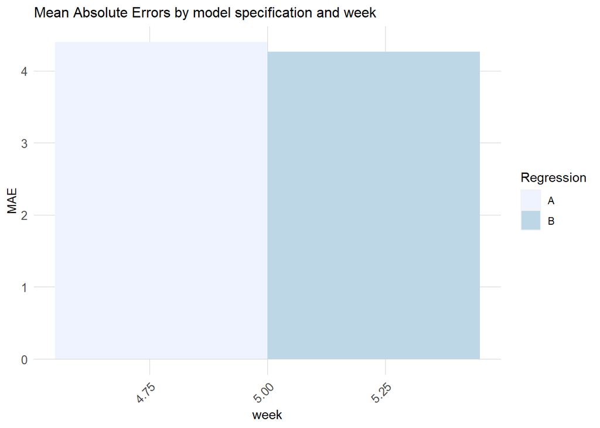

```r
week_predictions %>%
  dplyr::select(week, Regression, MAE) %>%
  gather(Variable, MAE, -Regression, -week) %>%
  ggplot(aes(week, MAE)) +
    geom_bar(aes(fill = Regression), position = "dodge", stat="identity") +
    scale_fill_manual(values = palette5) +
    labs(title = "Mean Absolute Errors by model specification and week") +
  plotTheme
```

### Time Series Plot

[figure not shown]

```r
week_predictions %>%
    mutate(interval60 = map(data, pull, interval60),
           from_id = map(data, pull, from_id)) %>%
    dplyr::select(interval60, from_id, Observed, Prediction, Regression) %>%
    unnest() %>%
    gather(Variable, Value, -Regression, -interval60, -from_id) %>%
    group_by(Regression, Variable, interval60) %>%
    summarize(Value = sum(Value)) %>%
    ggplot(aes(interval60, Value, colour=Variable)) +
      geom_line(size = 1.1) +
      facet_wrap(~Regression, ncol=1) +
      labs(title = "Predicted/Observed train delay time series", subtitle = "Greater NYC Metro Area; A test set of 2 weeks",  x = "Date", y= "Total Delay Minutes") +
      plotTheme
```

### CHECK

cv-kfolds

```r
fitControl <- trainControl(method = "cv", number = 5)
set.seed(825)

reg.cv <-
  train(delay_minutes ~ ., data = trip_panel %>%
                                dplyr::select(delay_minutes,line,holiday ,Temperature, Precipitation,Wind_Speed,Visibility,lagHour ,lag2Hours ,lag3Hours , lag12Hours , lag1day , holidayLag,leadHour,lead2Hours,lead3Hours,lead4Hours,lead12Hours,lead1day,from),
     method = "lm", trControl = fitControl, na.action = na.pass)
reg.cv
```

```
## Linear Regression
##
## 136833 samples
##     19 predictor
##
## No pre-processing
## Resampling: Cross-Validated (5 fold)
## Summary of sample sizes: 109467, 109466, 109466, 109467, 109466
## Resampling results:
##
##   RMSE      Rsquared   MAE
##   5.747007  0.0858952  3.311763
##
## Tuning parameter 'intercept' was held constant at a value of TRUE
```

### CHECK

cross-validation output

```r
reg.cv$resample[1:5,]
```

```
##       RMSE   Rsquared      MAE Resample
## 1 5.746038 0.07955221 3.310556    Fold1
## 2 5.828185 0.08208905 3.311627    Fold2
## 3 5.579050 0.08951548 3.278843    Fold3
## 4 5.616637 0.09121612 3.294539    Fold4
## 5 5.965125 0.08710313 3.363252    Fold5
```

# Conclusion + Suggestions

## Suggestions for Improvement

# Final Thoughts + App Wireframe

[https://www.figma.com/proto/63yCCvuvYQjDE8CXtZTpHd/Untitled?node-id=69%3A488&scaling=scale-down&page-id=0%3A1&starting-point-node-id=13%3A121]

# NOTES

What measures can be used to avoid prediction? What factors better predict train delays?

How good is the baseline model?

are we under predicting or over predicting?

Can we predict longer delays more accurately?